# How and Why to Use Models

Joseph Mullins

# When You Don’t Need a Model

## Causal Inference Without Deep Structure

- Many questions take the form: “What is the effect of $X$ on $Y$?”
- Often answerable with simple statistical models of causality (Potential Outcomes, Generalized Roy)
- No need to specify preferences, technology, or equilibrium
- But the target parameter must be precisely defined
- **Key requirement:** observed variation directly identifies the counterfactual of interest
- Three examples from our prototype models below

## Example: Social Security

- Consider the life-cycle savings model with a social security system
- The budget constraint:
  $$c_{t} + a_{t+1}/(1 + r) \leq (1-\tau)y_{t} + \mathbf{1}\{t\geq 65\}b$$
- Individuals receive benefit $b$ after age 65 and pay proportional taxes $\tau$
- Suppose eligibility is unexpectedly lowered from 65 to 60
- Repeated cross-sections of consumption by age and cohort are available

## Social Security: Target Parameter

- Let $t^*$ index cohorts by age at the time of the policy announcement
- $t^*$ indexes both a cohort *and* a treatment
- **Question:** *“What was the effect of this eligibility expansion on consumption at age $t$ for cohort $t^*$?”*
- $C_{t^*,t}(1)$: consumption under the announcement; $C_{t^*,t}(0)$: consumption absent the announcement
- Target parameter:
  $$\alpha_{t^*,t} = \mathbb{E}[C_{t^*,t}(1) - C_{t^*,t}(0)]$$
- Can we identify this without specifying the full model?

## Social Security: Difference-in-Differences

- Use the cohort aged 65 (unaffected) as a control group
- **Parallel trends:** for $t^*<65$, ages $t\geq t^*$ and $s < t^*$:
  $$\mathbb{E}[C_{t^*,t}(0)] - \mathbb{E}[C_{65,t}(0)] = \mathbb{E}[C_{t^*,s}(0)] - \mathbb{E}[C_{65,s}]$$
- The DD estimator constructs the counterfactual from observables:
  $$\alpha_{t^*,t} = \mathbb{E}[C_{t^*,t}(1)] - \mathbb{E}[C_{65,t}(0)] - \left(\mathbb{E}[C_{t^*,s}(0)] - \mathbb{E}[C_{65,s}(0)]\right)$$

## Social Security: Regression Specification

- The above was for a specific $(t^*, \text{control cohort}, s)$ triple
- With many cohorts and ages, the common regression:
  $$\mathbb{E}[C_{t^*,t}] = \gamma_{t^*} + \mu_{t} + \alpha_{t^*,t}\mathbf{1}\{t\geq t^*\}$$
- This layers in a stricter set of parallel trends assumptions
- No need to specify utility, discount factors, or savings technology
- Only need to defend parallel trends
- Farther-apart cohorts make this assumption stronger
- The regression cannot select “more ideal” controls for each treated cohort (Goodman-Bacon 2021)

## Example: Firm Entry and Minimum Wage

- Panel data $(A_{m,t,1}, A_{m,t,2}, Z_{m,t})$ on firm activity across markets
- $A_{m,t,j}$: whether firm $j$ is active in market $m$ at $t$; entry when $A_{m,t+1,j} - A_{m,t,j} = 1$
- $X_m$: unobservable market-level profitability shifter
- $Z \in \{0,1\}$: local minimum wage policy indicator
- Payoff to entering under the policy:
  $$u_{1}(x,a,d') = \phi_{0} + \phi_{1}x - \phi_{2}d' - \phi_{3}(1-a) + \phi_{4}z$$
- $\phi_4$ captures the minimum wage effect on firm payoffs

## Firm Entry: Target and Identification

- $Z_{m,1} = 0$ initially; a subset adopt permanently at $t^*$, unanticipated
- **Question:** *“What is the effect of the minimum wage on firm entry?”*
- $N_{m,t} = D_{m,t,1} + D_{m,t,2}$: number of active firms
- $N_{\tau,m}(z)$: potential outcome of $N$ in market $m$, $\tau$ periods after adoption
- Dynamic treatment effect on the treated:
  $$\alpha_{\tau} = \mathbb{E}[N_{\tau}(1) - N_{\tau}(0) \mid Z = 1]$$
- Effects differ across markets — heterogeneity matters
- Selection into adoption: $\mathbb{E}[\Delta_{\tau}|Z=1] \neq \mathbb{E}[\Delta_{\tau}]$

## Firm Entry: Parallel Trends

- Parallel trends justifying the event study:
  $$\mathbb{E}[N_{t}(0)|Z=1] - \mathbb{E}[N_{t}(0)|Z=0] = \text{constant}$$
- If markets are in the ergodic distribution of the MPE, $N$ is stationary absent intervention and parallel trends holds
- Event-study regression:
  $$D_{m,t} = \gamma_{m} + \mu_{t} + \mathbf{1}\{t\geq t^*\}\alpha_{t-t^*} + \epsilon_{m,t}$$
- Robustly identifies the average effect among adopters (uniform timing)
- With staggered adoption and heterogeneous effects, regression delivers a hard-to-interpret weighted average (Goodman-Bacon 2021)

## Example: Tax Reform Experiments

- Three states run different experiments with taxes and transfers
- Let $\mathcal{Y}_j$ be the net income function in state $j$:
  $$\begin{align}
  \mathcal{Y}_{A}(W,H) &= b_{A} + (1-\tau_{A})WH \\
  \mathcal{Y}_{B}(W,H) &= WH + \sum_{k=0}^{5}\tau_{k}(WH-\overline{E}_{k})\mathbf{1}\{WH>\overline{E}_{k}\} \\
  \mathcal{Y}_{C}(W,H) &= WH(1-\tau_{C}) + \mathbf{1}\{H>20\}b_{C}
  \end{align}$$
- Participants don’t anticipate assignment; the experiment is temporary (3 periods)
- $Z_j \in \{0,1\}$: assignment to treatment or control in state $j$

## Tax Reform: Identification

- **Question:** *“What is the effect of each unannounced, temporary reform on labor supply?”*
- Compare treatment and control means in each state:
  $$\mathbb{E}[H \mid Z_j = 1, j] - \mathbb{E}[H \mid Z_j = 0, j]$$
- Random assignment identifies the ATE — no further assumptions needed

# Reasons to Use a Model

## When the Question Requires One

- The most obvious reason: the research question cannot be articulated without a model
- The most useful modeling insights concern efficiency, market failures, and policy design
- What does the optimal tax and transfer system look like?
- What is the cheapest way to incentivize competition between firms?
- What are the welfare costs of incomplete insurance markets?
- These involve counterfactual policy environments never observed
- They require specifying objectives, constraints, and behavioral responses

## Welfare Calculations

- **Revealed preference:** treating individuals as knowing what they like lets us infer preferences and evaluate policy
- How do individuals value the social security program? How would they value a different $(\tau, b)$?
- What is the willingness to pay for a lump-sum transfer $b$ financed by taxes $\tau$? (We return to this below)

## Making Sense of Puzzling Data

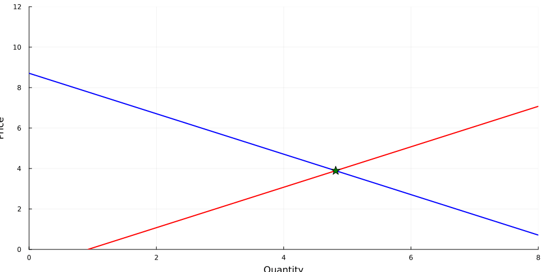

## Making Sense of Puzzling Data

- **With** supply and demand, each point is the equilibrium outcome of two structural relationships
- Wright proposed instrumental variables to disentangle supply from demand
- Perhaps the earliest estimated structural model

## When Variation Doesn’t Identify the Counterfactual

- In the examples above, we defined the “treatment” very specifically
- Models help articulate what can and cannot be identified by observed variation
- They outline assumptions under which related counterfactuals can be forecast, even without exact replication
- Often framed as *internal vs external validity* — but the “external validity” column is too rich to leave undiscussed

**Heckman and Vytlacil (2005)**

Estimands from simple statistical models designed to infer causal effects (IV, DD, RD) are rarely parameters of exact policy interest

## Social Security: A Concrete Case

To see what DD misses, simplify the savings model:

- Each individual faces a *known* income sequence $\{y_{n,t}\}_{t=1}^{T}$
- Agents face a *natural borrowing constraint*:
  $$\sum_{s=t}^{T}q_{s-t}c_{s} \leq a_{t} + \sum_{s=t}^{T}q_{s-t}(1-\tau)y_{n,s} + \sum_{s\geq 65}^{T}q_{s-t}b$$
  where $q_{\tau} = 1/(1+r)^{\tau}$ is the price of consumption $\tau$ periods ahead
- $\beta(1+r)=1$, $\psi = 0$: agents perfectly smooth consumption to NPV of net income

## Social Security: Consumption Effect

- Mean consumption effect for cohort $t^*$ at any $t \geq t^*$ equals the NPV effect of the announcement:
  $$\Delta C_{t^*,t} = \sum_{s=60}^{64}q_{s-t^*}b + \sum_{s=t^*}^{T}(\tau - \tau')\overline{y}_{t^*,t}$$
  where $\overline{y}_{t^*,t}$ is average income for cohort $t^*$ at age $t$
- Parallel trends holds: cross-cohort differences are constant with age ($\mu_t$ normalizable to zero)
- DD robustly identifies $\alpha_{t^*,t}$
- The model implies $\alpha_{t^*,t}$ is constant in $t$
- Each effect depends on **how cohort $t^*$ expects the expansion to be financed** ($\tau' - \tau$), which we haven’t specified

## Social Security: What DD Doesn’t Tell Us

- The $\alpha_{t^*,t}$ are informative but don’t tell us about *future* policy changes
- They don’t even tell us what would happen if the expansion were repealed
- Extrapolation requires more theory

DD does **not** identify:

- The total effect of social security (not just the expansion)
- Effects of additional changes in the eligibility age
- Effects of changes in $b$ and $\tau$ at different ages and anticipation horizons
- Effects on cohort $t^*$ if they learned at any age other than $t^*$ (one-to-one mapping between cohort and treatment)
- Effects for cohorts who anticipated the policy their whole life
- Effects under alternative financing arrangements

## Tax Reform: What the Model Reveals

- Effect of reform $A$ when $\beta(1+r) = 1$ (stationary consumption):
  $$\Delta H_{n,t} = \psi\log(1-\tau) - \psi\sigma\Delta \log\left(C^*_{n}\right)$$
- $\Delta C^*_n$ embodies the income effect; solved by plugging optimal labor supply into the intertemporal budget constraint
- The ATE depends on income effects, which depend on the *perceived persistence* of the reform
- Substantial heterogeneity in treatment effects
- Different distributions of wages or work costs across populations imply different impacts

## Tax Reform: What Experiments Don’t Tell Us

Each experiment robustly identifies the effect of reform $j$ on population $j$. It does **not** identify:

- Effects of reforms with different persistence — experimental findings must be interpreted carefully regarding perceived duration
- The effect of reform $A$ on population $B$, or vice versa
- The distribution of individual treatment effects
- Effects of partly anticipated reforms
- Effects at scale, where general equilibrium responses may appear
- The model can invert out wage and work cost distributions from panel data, then return to the experimental data to estimate ATEs along latent dimensions

## Entry-Exit: What the Event Study Doesn’t Tell Us

The model-free approach does not identify:

- The effect when the minimum wage introduction is anticipated
- The effect on markets that do *not* adopt
- The effect of repealing the minimum wage
- The effect of nominal changes to the minimum wage
- Each of these is arguably a more useful or compelling policy calculation

## Interpolating Variation

- Each tax reform is related: each takes the form $\mathcal{Y}(W,H)$ over wages and hours
- Estimating labor supply as a nonparametric function of $\mathcal{Y}$ would require implausible amounts of policy variation
- Models **interpolate** related — but not functionally identical — variation
- In the labor supply model, any $\mathcal{Y}$ enters through the budget constraint — different reforms are comparable without new parameters
- See Mullins (2026) for a similar exercise with welfare reform experiments

## Articulated Variation

- **Articulated variation:** when a policy’s effect can be modeled without additional parameters
- Typically involves *a priori* known changes to prices and endowments
- With structural parameters in hand, any observed variation in $\mathcal{Y}$ can be interpreted through the model
- **Counterexample:** the minimum wage in the entry-exit model
- Embodied as a reduced-form parameter $\phi_4$ because within-period production is not modeled
- The policy is *not* well-articulated: further nominal wage changes cannot be studied

# Marschak’s Maxim

## The Principle

- We’ve explored the boundaries of causal inference and where modeling adds value
- Less instructive for *how* to do economic modeling
- More art than science — but Marschak’s Maxim is a useful guiding principle

**Marschak’s Maxim (Marschak 1953; Heckman and Vytlacil 2007)**

Researchers should specify the minimal set of model ingredients needed to answer their research question of interest

## Marschak’s Maxim: In Practice

- This may seem obvious — the hard part is figuring out what the minimal set is
- Surprisingly easy to forget once deep inside your model
- *“Is this ingredient essential to my question?”* — ask repeatedly
- Your research question is the mast you tie yourself to
- Decide what it is as early as possible

## Marschak’s Original Example: Setup

- A monopolist chooses quantities to maximize profit; the government taxes quantities
- Demand: $p = \alpha_0 - \alpha_1 q$
- Profits (constant marginal cost $c$):
  $$\Pi(q) = (\alpha_0 - c - \tau)q - \alpha_1 q^2$$
- Optimal quantity and tax revenue:
  $$q^* = \frac{\alpha_0 - c - \tau}{2\alpha_1}, \qquad R = \frac{(\alpha_0 - c - \tau)\tau}{2\alpha_1}$$

## Marschak’s Original Example: Three Problems

Suppose $q$ varies exogenously across markets. Three problems, three information requirements:

1. **Firm maximizing profit:** observe $\Pi = aq - bq^2$, set $q^* = a/2b$
2. **Government forecasting revenue:** only needs $\tau$ and observed quantities
3. **Government optimizing taxes:** extract $a = \alpha_0 - c - \tau$ from the reduced form, set $\tau^* = (\alpha_0 - c)/2$
- The setup is unconventional — we typically assume agents already act optimally

## Lessons from Marschak’s Example

Two insights:

1. Each question requires only certain *combinations* of parameters, each observable in reduced-form relationships
2. Once agents optimize, reduced-form relationships no longer suffice for forecasting policy effects
- Point (2) is the Lucas Jr (1976) critique, articulated two decades earlier
- Point (1): answers to some questions are invariant to particular model ingredients
- In practice we can’t always guarantee this, but the insight motivates seeking a minimal set of ingredients

## Two-Stage Budgeting

- Utility over $K$ commodities $x$ with price vector $p$:
  $$V_t(p,a,y) = \max_{x,a'} \left\{ v(x) + \beta\, \mathbb{E}\, V_{t+1}(p',a',y') \right\}$$
  subject to:
  $$p \cdot x + \frac{1}{1+r}a' \leq y_t,\qquad a \geq \underline{a}$$
- Suppose the question concerns savings accumulation and intertemporal policy counterfactuals

## Two-Stage Budgeting: The Result

- If $v$ is homothetic, there exists a price index $P(p)$ and indirect utility $u$ such that (Gorman 1959):
  $$V(p,X) = u(X / P(p))$$
- Consumers first allocate aggregate expenditure across periods, then allocate within periods separately
- Classic application of Marschak’s Maxim: if your question is about intertemporal allocation and counterfactuals don’t affect intratemporal margins, no need to model intratemporal consumption under regularity conditions
- All you need is a reasonable price index
- Gorman (1959) and others sought assumptions permitting broader expenditure categories in demand systems

## Sufficient Statistics: Setup

- Static labor supply for $i \in [0,1]$: $H_i = \arg\max_h\; C - v(h)$, with $C = b + (1-\tau)hW_i$
- Transfer financed through taxes: $b = \tau \int W_i H_i\, di$
- Utilitarian welfare objective:
  $$V(\tau) = \int (C_i - v(H_i))\, di$$
- What is the welfare effect of a marginal expansion in $b$, financed through $\tau$?

## Sufficient Statistics: Derivation

- Applying the envelope theorem:
  $$\frac{dV}{d\tau} = -\int W_iH_i\,di + \int W_iH_i\,di + \tau \int \frac{d(W_iH_i)}{d\tau}\, di$$
- Assuming a constant elasticity of taxable income $Z_i = W_iH_i$ w.r.t. $\tau$:
  $$\frac{dV}{d\tau} = \bar{Z}\; \varepsilon_{Z,\tau}$$
- The willingness to pay for the transfer **exactly cancels** the mechanical tax cost
- Only the **distortionary cost** of behavioral adjustments remains (Harberger 1954)

## Sufficient Statistics: Scope and Limits

- A larger literature on *sufficient statistics* in public finance derives approximations to local policy effects
- Welfare formulas depending on empirical quantities and elasticities
- Less reliance on specific functional forms
- As models grow more elaborate, required elasticities can become intractable (Kleven 2021)
- Sufficient statistics remain a useful guide to understanding policy fundamentals
- A great example of Marschak’s Maxim!

# Summary

## Takeaways

- Quasi-experimental methods are powerful when observed variation directly identifies the counterfactual
- Models become essential for **welfare**, **optimal policy**, or **out-of-sample counterfactuals**
- Models interpolate related variation through articulated policy channels — connecting different reforms through the same structural parameters
- **Marschak’s Maxim:** always aim for the minimal set of ingredients your question requires

## References

Goodman-Bacon, Andrew. 2021. “Difference-in-Differences with Variation in Treatment Timing.” *Journal of Econometrics* 225 (2): 254–77. https://doi.org/https://doi.org/10.1016/j.jeconom.2021.03.014.

Gorman, W. M. 1959. “Separable Utility and Aggregation.” *Econometrica* 27 (3): 469–81. http://www.jstor.org/stable/1909472.

Harberger, Arnold C. 1954. “Monopoly and Resource Allocation.” *The American Economic Review* 44 (2): 77–87. http://www.jstor.org/stable/1818325.

Heckman, James, and Edward Vytlacil. 2005. “Structural equations, treatment effects, and econometric policy evaluation.” *Econometrica* 73 (3): 669–738.

———. 2007. “Chapter 70 Econometric Evaluation of Social Programs, Part i: Causal Models, Structural Models and Econometric Policy Evaluation.” In, edited by James J. Heckman and Edward E. Leamer, 6:4779–874. Handbook of Econometrics. Elsevier. https://doi.org/https://doi.org/10.1016/S1573-4412(07)06070-9.

Kleven, Henrik J. 2021. “Sufficient Statistics Revisited.” Journal Article. *Annual Review of Economics* 13 (Volume 13, 2021): 515–38. https://doi.org/https://doi.org/10.1146/annurev-economics-060220-023547.

Lucas Jr, Robert E. 1976. “Econometric Policy Evaluation: A Critique.” In *Carnegie-Rochester Conference Series on Public Policy*, 1:19–46. North-Holland.

Marschak, Jacob. 1953. “Economic Measurements for Policy and Prediction.” In *Studies in Econometric Method*, edited by W. Hood and C. Koopmans. John Wiley & Sons.

Mullins, Joseph. 2026. “A Structural Meta-Analysis of Welfare Reform Experiments and Their Impacts on Children.” *Journal of Political Economy* 134 (1): 435–77. https://doi.org/10.1086/738482.